# Raminski UCB R Class Asgt 1

## Diary

I had some trouble starting the assignment because I was still grasping the concept of a “Markdown” file- format, purpose, how to build, etc.

Additionally, I downloaded MiKTeX, but had some trouble at the beginning generating a Markdown file in Word. Attempting to do so gave me an error message that said that MiKTeX was not installed. However, that seems to have been resolved somehow and now I do have the option of generating a Word Markdown file (although I will submit in html)

## Summary of Results

The results generated were largely as expected especially since I had read the materials before completing the assignment.

However, I was still not sure how to summarize the large “Arthritis” table. When I added “results=hide” to the code, I was given an error message. I am still curious about the correct way to either summarize or hide the results entirely.

## Kabacoff Section 1.8

1. Open the general help, and look at the “Introduction to R” section

```r
help.start()
```

```
## If nothing happens, you should open
## 'http://127.0.0.1:30069/doc/html/index.html' yourself
```

2. Install the vcd package (code not run)

install.packages(“vcd”)

3. List the functions and datasets available in this package

```r
help(package="vcd")
```

4. Load the package, and read the description of dataset Arthritis

```r
library(vcd)
```

5. Print out the Arthritis dataset

```r
Arthritis
```

```
##    ID Treatment    Sex Age Improved
## 1  57   Treated   Male  27     Some
## 2  46   Treated   Male  29     None
## 3  77   Treated   Male  30     None
## 4  17   Treated   Male  32   Marked
## 5  36   Treated   Male  46   Marked
## 6  23   Treated   Male  58   Marked
## 7  75   Treated   Male  59     None
## 8  39   Treated   Male  59   Marked
## 9  33   Treated   Male  63     None
## 10 55   Treated   Male  63     None
## 11 30   Treated   Male  64     None
## 12  5   Treated   Male  64     Some
## 13 63   Treated   Male  69     None
## 14 83   Treated   Male  70   Marked
```

[output cut: 70 more lines]

6. Run the example that comes with the Arthritis dataset

```r
example(Arthritis)
```

```
##
## Arthrt> data("Arthritis")
##
## Arthrt> art <- xtabs(~ Treatment + Improved, data = Arthritis, subset = Sex == "Female")
##
## Arthrt> art
##          Improved
## Treatment None Some Marked
##   Placebo   19    7      6
##   Treated    6    5     16
##
## Arthrt> mosaic(art, gp = shading_Friendly)
```

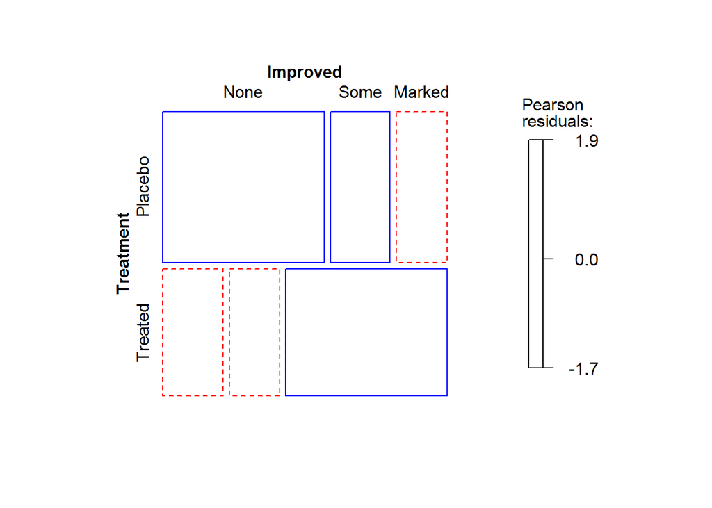

```
##
## Arthrt> mosaic(art, gp = shading_max)
```

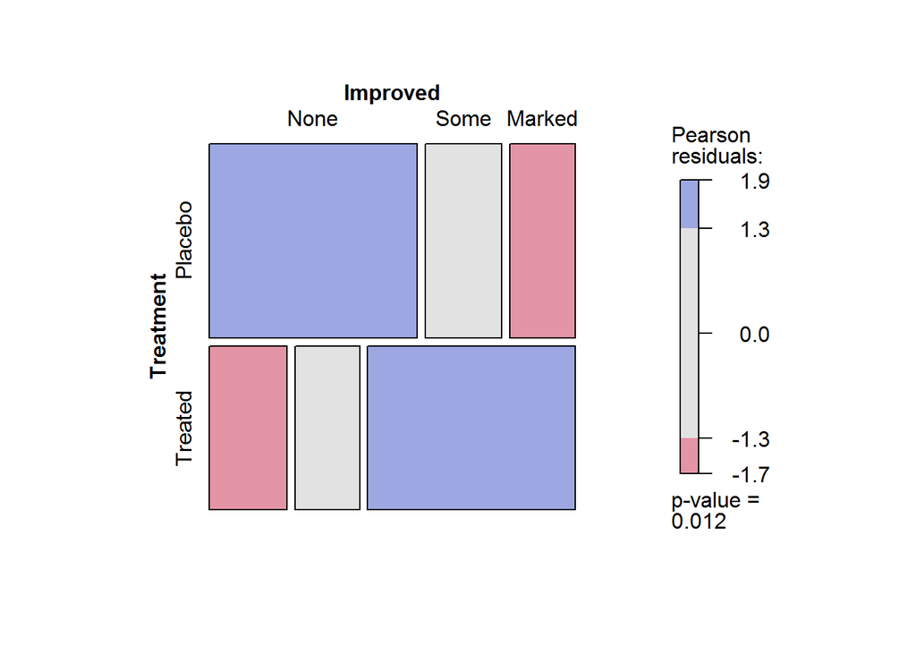

7. Quit (code not run)

q()

## Teetor Section 5.1-5.19

### Section 5.1

Appending a single item in a vector

```r
v <- c(1,2,3)
v <- c(v,4) # Append a single value to v
v
```

```
## [1] 1 2 3 4
```

Appending multiple items in a vector

```r
w <- c(5,6,7,8)
v <- c(v,w) # Append an entire vector to v
v
```

```
## [1] 1 2 3 4 5 6 7 8
```

Append an items by assigning it to a poistion in a vector

```r
v <- c(1,2,3) # Create a vector of three elements
v[10] <- 10 # Assign to the 10th element
v # R extends the vector automatically
```

```
##  [1]  1  2  3 NA NA NA NA NA NA 10
```

### Section 5.2

Insert an item into a vector

```r
append(1:10, 99, after=5)
```

```
##  [1]  1  2  3  4  5 99  6  7  8  9 10
```

Insert an item into a vector

```r
append(1:10, 99, after=0)
```

```
##  [1] 99  1  2  3  4  5  6  7  8  9 10
```

### Section 5.3

The “recycling rule” - handling vectors of different lengths

```r
c (1:3)
```

```
## [1] 1 2 3
```

```r
c (1:6)
```

```
## [1] 1 2 3 4 5 6
```

```r
(1:6) + (1:3)
```

```
## [1] 2 4 6 5 7 9
```

Use “cbind” to create column vectors

```r
cbind (1:3)
```

```
##      [,1]
## [1,]    1
## [2,]    2
## [3,]    3
```

```r
cbind (1:6)
```

```
##      [,1]
## [1,]    1
## [2,]    2
## [3,]    3
## [4,]    4
## [5,]    5
## [6,]    6
```

```r
cbind((1:6), (1:3))
```

```
##      [,1] [,2]
## [1,]    1    1
## [2,]    2    2
## [3,]    3    3
## [4,]    4    1
## [5,]    5    2
## [6,]    6    3
```

If shorter vector is not a multiple of the larger vector then R generates a warning

```r
(1:5) + (1:6)
```

```
## Warning in (1:5) + (1:6): longer object length is not a multiple of shorter
## object length
```

```
## [1]  2  4  6  8 10  7
```

Add a scalar value to a vector

```r
(1:6) + 10
```

```
## [1] 11 12 13 14 15 16
```